# How to design different color palettes in R

John Shorter

Feb/21/2024

# Introduction

Color palette is an important aspect of plots. They make the plots prettier and easy to read. The quality of the plots is part of the quality of the work. If your plots are nice, people take them more seriously. A color palette is a pre-defined set of colors to be used in making plots.

The desired properties of a color palette include:

1. Colorblind friendly;
2. Easily discernible colors - the colors are not too similar to each other;
3. Pretty.

You can design your own color palette in R. This workbook demonstrates how to do that.

# load packages

You might need to install some of these packages

```r
install.packages("maps")
install.packages("viridis")
install.packages("mapproj")
library(ggplot2)
library(tidyr)
library(dplyr)
library(RColorBrewer)
library(viridis)
```

`RColorBrewer` and `viridis` are two packages of pre-made color palettes that you can use.

# Data

we will simulate some data

```r
data <- data.frame(
  treatment = c("1", "2", "3", "4", "5", "6", "7"),
  response = c(10, 20, 30, 40, 50, 60, 70)
)

head(data)
```

```
##   treatment response
## 1         1       10
## 2         2       20
## 3         3       30
## 4         4       40
## 5         5       50
## 6         6       60
```

## RColorBrewer

RColorBrewer has some pre-made color palettes that you can use if you don’t bother to make your own. They are pretty good! To set the colors or fill, use `scale_color_brewer()` or `scale_fill_brewer()`. You can look at all the palattes here.

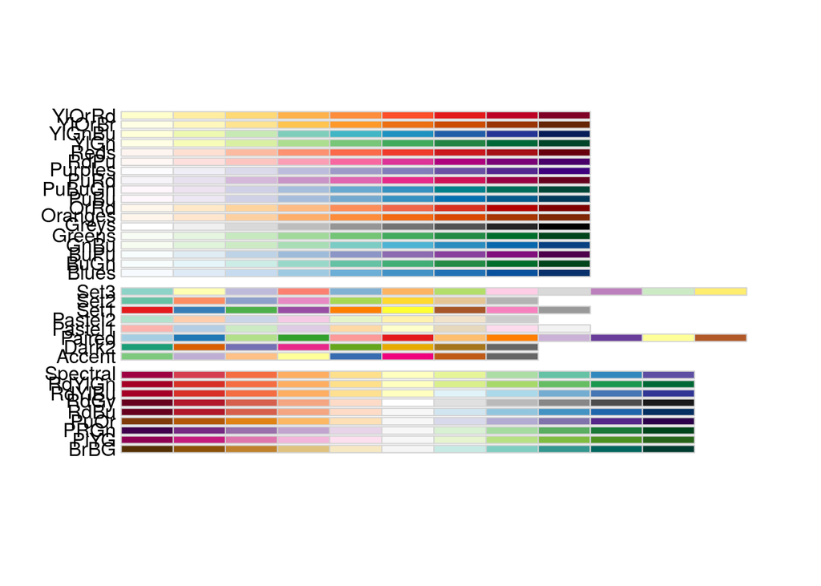

```r
RColorBrewer::display.brewer.all()
```

(FYI: If your output shows in line with your code, to the upper left corner of the output, there is a “show in new window” button. Click that and drag the window longer to see it better. If your output shows up in the Plots area at the lower right hand side, you can click “Zoom”)

There are three groups of palettes.

The top group is continuous unidirectional. They are meant for variables that are from 0 to Inf (or -Inf).

The second group is qualitative. This is meant for discrete variables.

The third group is continuous bidirectional. They are meant for variables ranging from -Inf to Inf, with both positive and negative values.

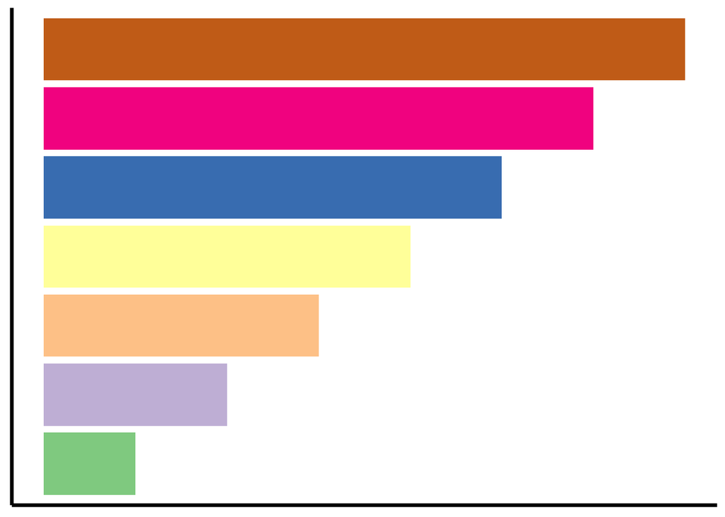

```r
data %>%
  ggplot(aes(x = treatment, y = response)) +
  geom_bar(stat = "identity", aes(fill = treatment)) +
  scale_fill_brewer(palette = "Accent") + #call the palette here
  labs(x = NULL,
       y = NULL) +
  theme_minimal() +
  theme(legend.position = "none",
        axis.line = element_line(linewidth = 1.2),
        text = element_text(size = 12, face = "bold", color = "black"),
        axis.text = element_blank(),
        panel.grid = element_blank()
        ) +
  coord_flip()
```

This is the “Accent” palette from `RColorBrewer`. If you use `scale_fill_brewer(palette = "Accent")` you can specify the Accent palette from `RcolorBrewer`.

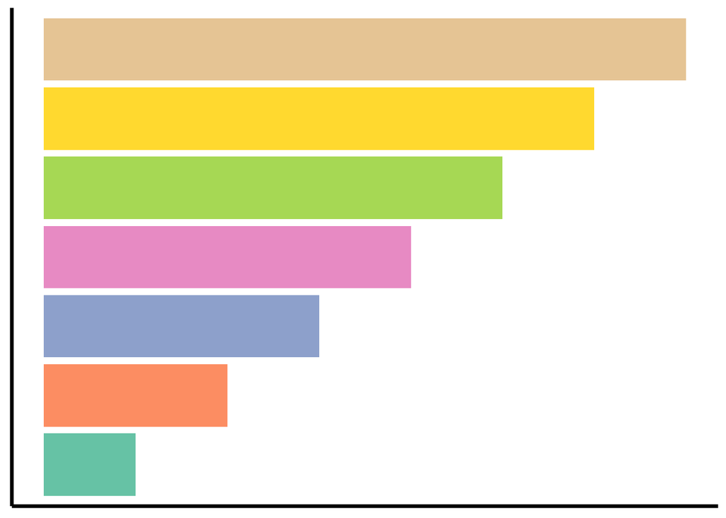

```r
data %>%
  ggplot(aes(x = treatment, y = response)) +
  geom_bar(stat = "identity", aes(fill = treatment)) +
  scale_fill_brewer(palette = "Set2") + #call the palette here
  labs(x = NULL,
       y = NULL) +
  theme_minimal() +
  theme(legend.position = "none",
        axis.line = element_line(size = 1.2),
        text = element_text(size = 12, face = "bold", color = "black"),
        axis.text = element_blank(),
        panel.grid = element_blank()
        ) +
  coord_flip()
```

This is the “Set2” palette from `RColorBrewer`.

# Example 1 - “wisteria”

Now let’s make our own palette.

Wisteria is a color palette, inspired by the beautiful flowers of the [wisteria vines](https://en.wikipedia.org/wiki/Wisteria).

If you want a beautiful palette, a good place to start is flowers.

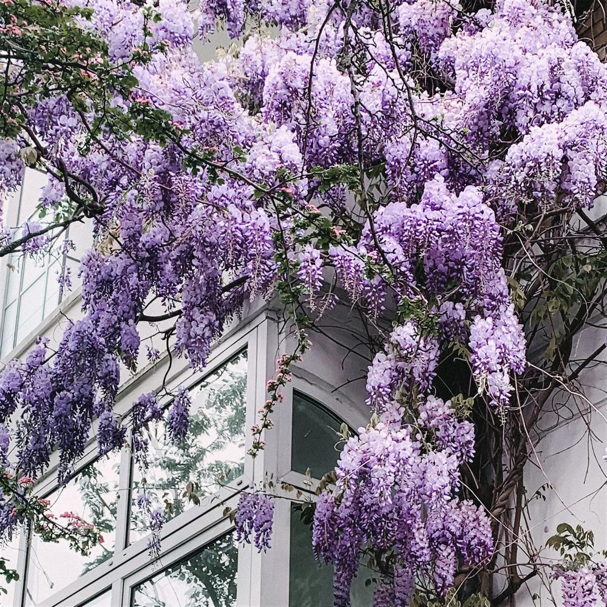

wisteria picture

```r
wisteria <-
  c("grey65", "burlywood3", "khaki2", "plum1", "lightcyan2", "cornflowerblue", "slateblue3")
```

Most of the experiments have less than 7 treatments, so 7 colors should be good enough.

R has a bunch of built-in color names. You can directly call their names (in ” “) in ggplot, and ggplot will show that color. [Link to R color names](http://www.stat.columbia.edu/~tzheng/files/Rcolor.pdf)

You can save the palette as a character string of different color names using `c()`.

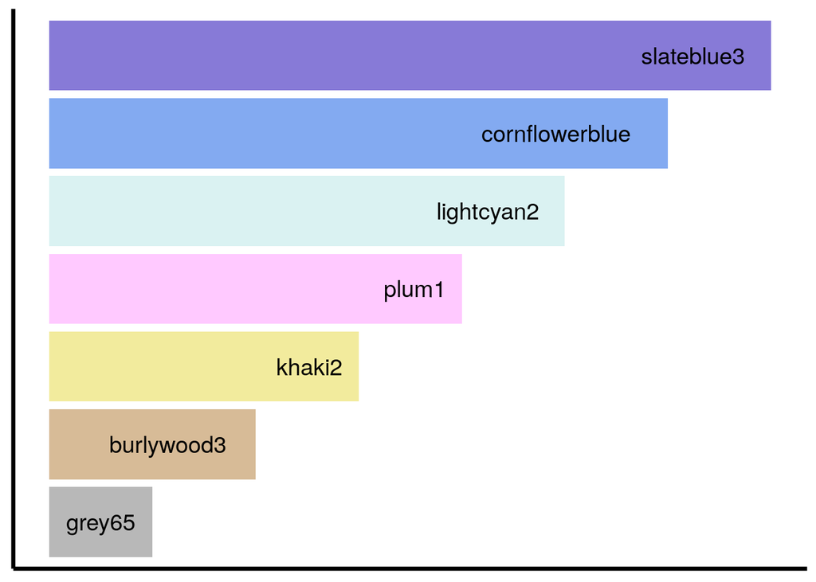

```r
data %>%
  cbind(wisteria) %>%
  ggplot(aes(x = treatment, y = response)) +
  geom_bar(stat = "identity", aes(fill = treatment), alpha = 0.8) +  # this is alpha = 0.8, or 20% transparent
  geom_text(aes(label = wisteria, y = response), size = 5, hjust = 1.25) +
  scale_fill_manual(values = wisteria) + #call the palette here
  labs(x = NULL,
       y = NULL) +
  theme_minimal() +
  theme(legend.position = "none",
        axis.line = element_line(size = 1.2),
        text = element_text(size = 12, face = "bold", color = "black"),
        axis.text = element_blank(),
        panel.grid = element_blank()
        ) +
  coord_flip()
```

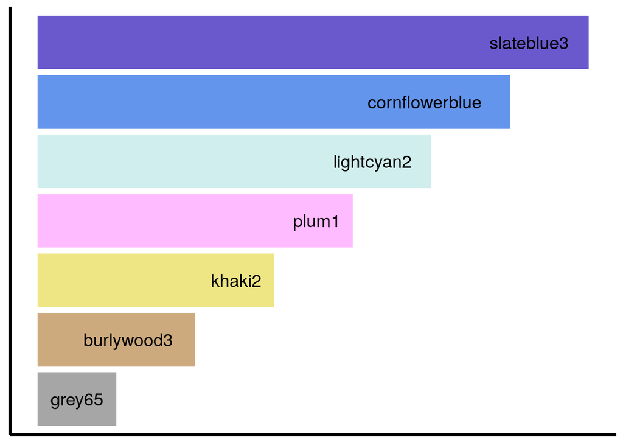

```r
data %>%
  cbind(wisteria) %>%
  ggplot(aes(x = treatment, y = response)) +
  geom_bar(stat = "identity", aes(fill = treatment), alpha = 1) +  # this is alpha = 1, or 0% transparent
  geom_text(aes(label = wisteria, y = response), size = 5, hjust = 1.25) +
  scale_fill_manual(values = wisteria) + #call the palette here
  labs(x = NULL,
       y = NULL) +
  theme_minimal() +
  theme(legend.position = "none",
        axis.line = element_line(size = 1.2),
        text = element_text(size = 12, face = "bold", color = "black"),
        axis.text = element_blank(),
        panel.grid = element_blank()
        ) +
  coord_flip()
```

Can you tell the differences between colors? Yes? Good.

## How do I check if my palette is colorblind friendly?

There is free software called [“Color Oracle”](http://colororacle.org/). It simulate colorblindness on your computer. If you can still discern the colors after you turn on “Deuteranopia”, it should be good.

# Example2 - Higanbana

Higanbana is another palette, based on the [red spider lily](https://en.wikipedia.org/wiki/Lycoris_radiata)

[figure not shown]

picture of red spider lily

Again if you want beautiful palettes, flowers is a good place to start. Colorful fishes is a good place to start too.

## Pick colors

What can I do if I don’t want to be confined by pre-existing colors in R?

For Windows: [“takecolor” is a free app](https://download.cnet.com/TakeColor/3000-2192_4-10387506.html). After unzipping, run the `.exe` file. Hover your mouse on the color. Alt + C will record the color.

For MAC: OS X comes with DigitalColor Meter: Applications > Utilities > Digital Color Meter.app It has many options and preferences. command+shift+c will copy the color under the cursor to the clipboard in many different formats.

```r
Higanbana <- c(
  "#FED731",
  "#FDA888",
  "#EF5960",
  "#E70F25",
  "#8C030B",
  "#450110",
  "#1F0A0A"
)
```

These are the colors I picked from higanbana photos. Note: these color names are in the “hex code” format. The first two digits are red; second two are green; last two are blue. Each digit goes from 0 to F (16-nary), or 0 to 255 (16^2 - 1).

- White is #FFFFFF
- Black is #000000
- Red is #FF0000
- Green is #00FF00
- Blue is #0000FF

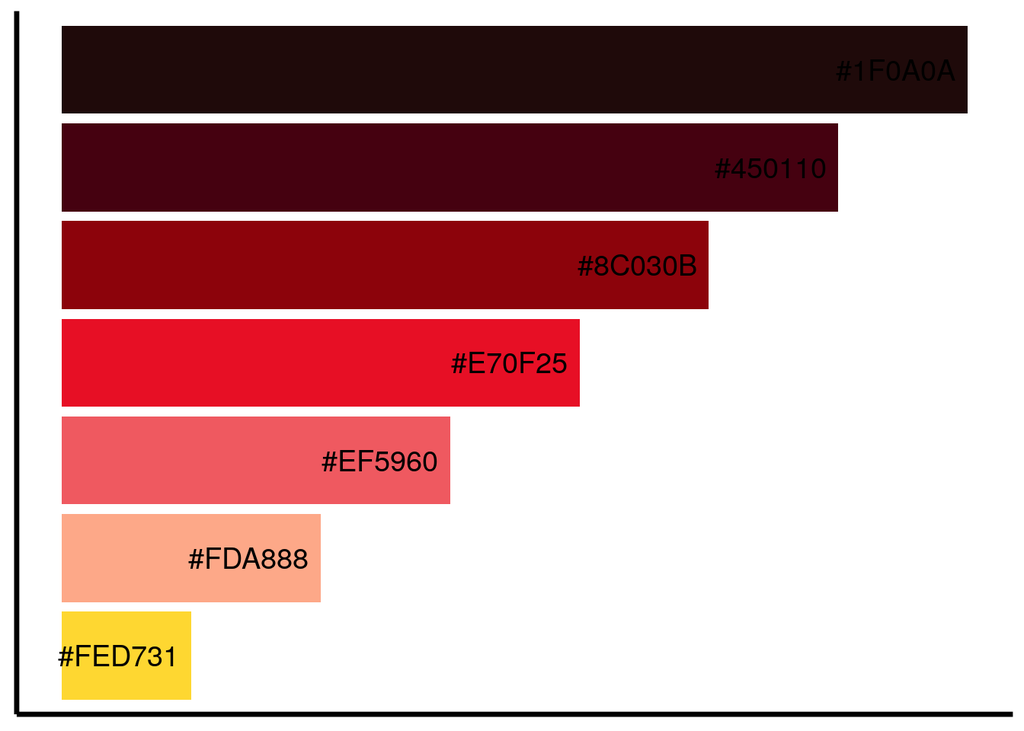

```r
data %>%
  cbind(Higanbana)%>%
  ggplot(aes(x = treatment, y = response)) +
  geom_bar(stat = "identity", aes(fill = treatment), alpha = 1) + # this is alpha = 1, or 0% transparent
  geom_text(aes(label = Higanbana, y = response), size = 5, hjust = 1.1) +
  scale_fill_manual(values = Higanbana) + #call the palette here
  labs(x = NULL,
       y = NULL) +
  theme_minimal() +
  theme(legend.position = "none",
        axis.line = element_line(size = 1.2),
        text = element_text(size = 12, face = "bold", color = "black"),
        axis.text = element_blank(),
        panel.grid = element_blank()
        ) +
  coord_flip()
```

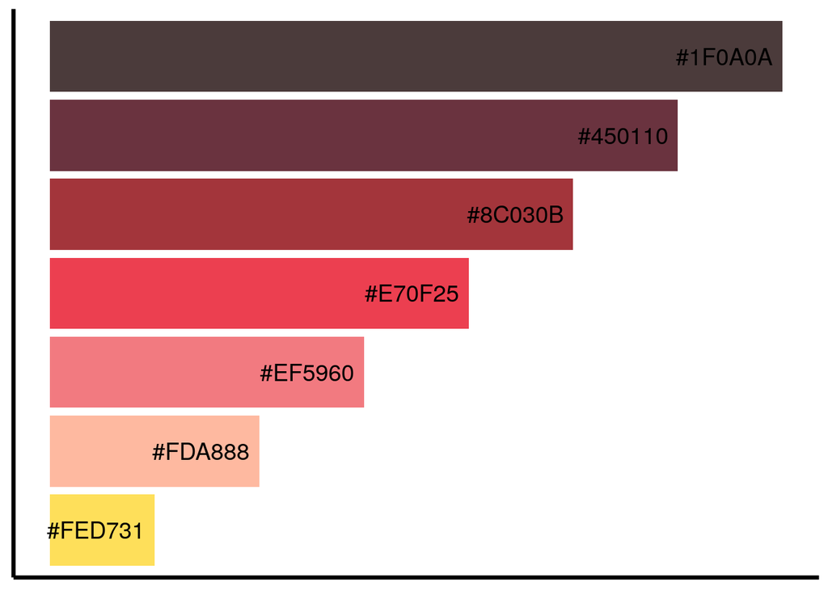

```r
data %>%
  cbind(Higanbana)%>%
  ggplot(aes(x = treatment, y = response)) +
  geom_bar(stat = "identity", aes(fill = treatment), alpha = 0.8) + # this is alpha = 0.8, or 20% transparent
  geom_text(aes(label = Higanbana, y = response), size = 5, hjust = 1.1) +
  scale_fill_manual(values = Higanbana) + #call the palette here
  labs(x = NULL,
       y = NULL) +
  theme_minimal() +
  theme(legend.position = "none",
        axis.line = element_line(size = 1.2),
        text = element_text(size = 12, face = "bold", color = "black"),
        axis.text = element_blank(),
        panel.grid = element_blank()
        ) +
  coord_flip()
```

Can you tell the differences between colors? Yes? Good.

Again check with Color Oracle to see if your colors are colorblind friendly. If you can still discern the colors after you turn on “Deuteranopia”, it should be good.

# How can I design continous color gradients?

## The continuous color palettes from RColorBrewer

As I showed earlier, `RColorBrewer` has a set of pre-made continuous palette that you can use.

## The viridis package

The best continuous color gradients are always the viridis color maps. You can read more [here](https://cran.r-project.org/web/packages/viridis/vignettes/intro-to-viridis.html)

The viridis package contain 4 color scales: viridis, magma, plasma and inferno. They are all designed specifically for continuous color gradients. They are all colorblind friendly, as well as gray-scale friendly, meaning if you print them out in black and white, you can still read them.

Here’s a demonstration of the “inferno” option in viridis.

```r
library(maps)
#you might need to install the packages "maps" and "mapproj"
```

```r
#load some data. Don't worry about this chunk
unemp <- read.csv("http://datasets.flowingdata.com/unemployment09.csv",
                  header = FALSE, stringsAsFactors = FALSE)
names(unemp) <- c("id", "state_fips", "county_fips", "name", "year",
                  "?", "?", "?", "rate")
unemp$county <- tolower(gsub(" County, [A-Z]{2}", "", unemp$name))
unemp$county <- gsub("^(.*) parish, ..$","\\1", unemp$county)
unemp$state <- gsub("^.*([A-Z]{2}).*$", "\\1", unemp$name)

county_df <- map_data("county", projection = "albers", parameters = c(39, 45))

names(county_df) <- c("long", "lat", "group", "order", "state_name", "county")
county_df$state <- state.abb[match(county_df$state_name, tolower(state.name))]
county_df$state_name <- NULL

state_df <- map_data("state", projection = "albers", parameters = c(39, 45))

choropleth <- merge(county_df, unemp, by = c("state", "county"))
choropleth <- choropleth[order(choropleth$order), ]
```

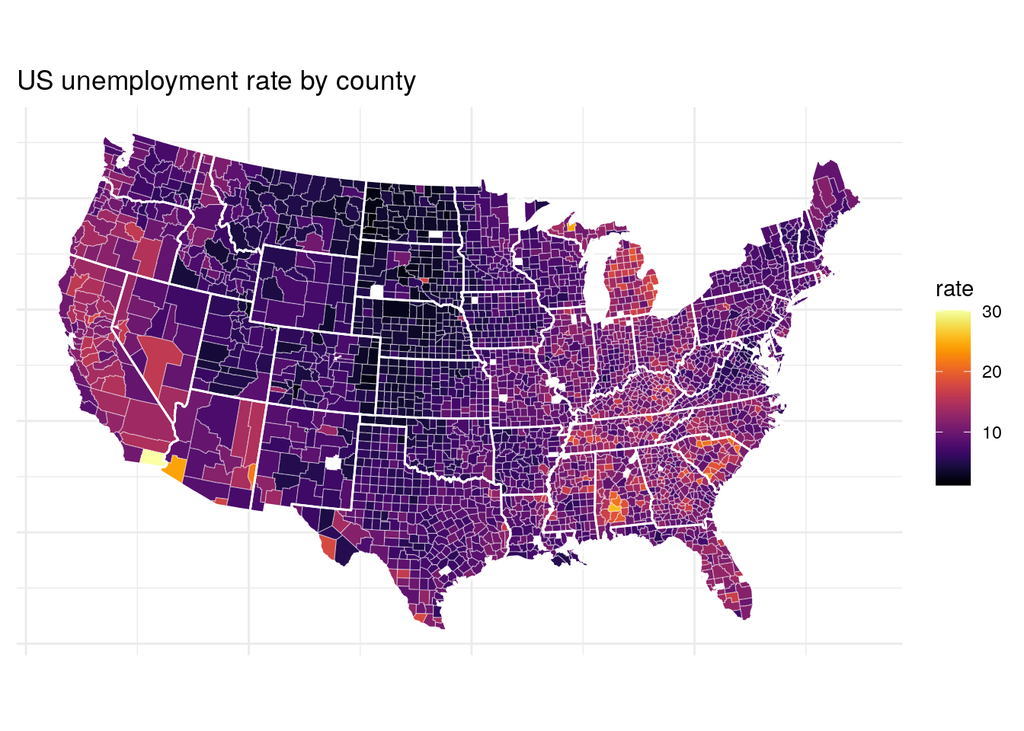

```r
ggplot(choropleth, aes(long, lat, group = group)) +
  geom_polygon(aes(fill = rate), colour = alpha("white", 1 / 2), size = 0.2) +
  geom_polygon(data = state_df, colour = "white", fill = NA) +
  coord_fixed() +
  theme_minimal() +
  ggtitle("US unemployment rate by county") +
  theme(axis.line = element_blank(), axis.text = element_blank(),
        axis.ticks = element_blank(), axis.title = element_blank()) +
  scale_fill_viridis(option="inferno")
```

This is the “inferno” option from viridis

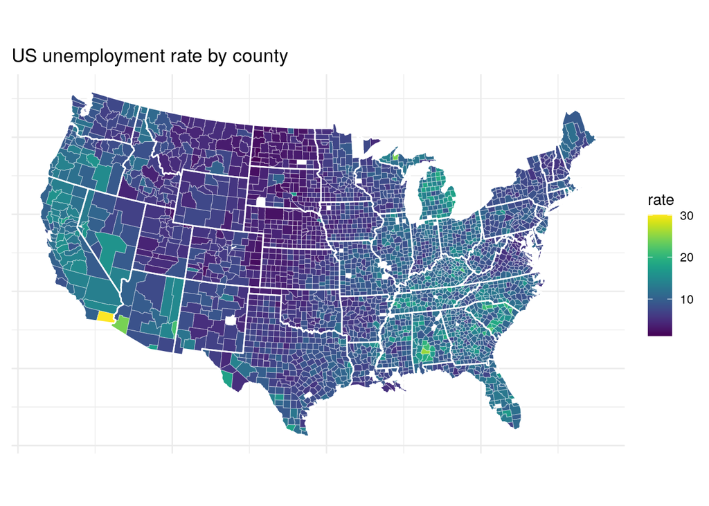

```r
ggplot(choropleth, aes(long, lat, group = group)) +
  geom_polygon(aes(fill = rate), colour = alpha("white", 1 / 2), size = 0.2) +
  geom_polygon(data = state_df, colour = "white", fill = NA) +
  coord_fixed() +
  theme_minimal() +
  ggtitle("US unemployment rate by county") +
  theme(axis.line = element_blank(), axis.text = element_blank(),
        axis.ticks = element_blank(), axis.title = element_blank()) +
  scale_fill_viridis(option="viridis")
```

This is the “viridis” option from viridis.

# Exercise

## Make your own color palette!

You can see these two examples below. Make your own color pattern, then plot it using the code chunk below.

R has a bunch of built-in color names. You can directly call their names (in ” “) in ggplot, and ggplot will show that color. [Link to R color names](http://www.stat.columbia.edu/~tzheng/files/Rcolor.pdf)

You can save the palette as a character string of different color names using `c()`.

```r
Higanbana_c <- c(
  "#FFE0A0",
  "#FDA888",
  "#EF5960",
  "#E70F25",
  "#8C030B",
  "#450110",
  "#000000"
) %>%
  rev()
```

```r
wisteria <-  c(
  "grey65",
  "burlywood3",
  "khaki2",
  "plum1",
  "lightcyan2",
  "cornflowerblue",
  "slateblue3")
```

Make your own here. Uncomment these lines first

```r
# my_colors
```

```r
# data %>%
#   cbind(my_colors) %>%
#   ggplot(aes(x = treatment, y = response)) +
#   geom_bar(stat = "identity", aes(fill = treatment), alpha = 1) +
#   geom_text(aes(label = my_colors, y = response), size = 5, hjust = 1.25) +
#   scale_fill_manual(values = my_colors) +
#   labs(x = NULL,
#        y = NULL) +
#   theme_minimal() +
#   theme(legend.position = "none",
#         axis.line = element_line(size = 1.2),
#         text = element_text(size = 12, face = "bold", color = "black"),
#         axis.text = element_blank(),
#         panel.grid = element_blank()
#         ) +
#   coord_flip()
```